# Case Study: Loan Payback Prediction

[figure not shown]

# Introduction

LendingClub is a US peer-to-peer lending company, headquartered in San Francisco, California. It was the first peer-to-peer lender to register its offerings as securities with the Securities and Exchange Commission (SEC), and to offer loan trading on a secondary market. LendingClub is the world's largest peer-to-peer lending platform.

**Problem:**

- Given historical data on loans given out with information on whether or not the borrower defaulted (charge-off), build a model that can predict whether or nor a borrower will pay back their loan. This way in the future when a new potential customer, they can assess whether or not they are likely to pay back the loan.

**Dataset:*

- Historical data of LendingClub

**Source:** https://www.lendingclub.com/

# Review

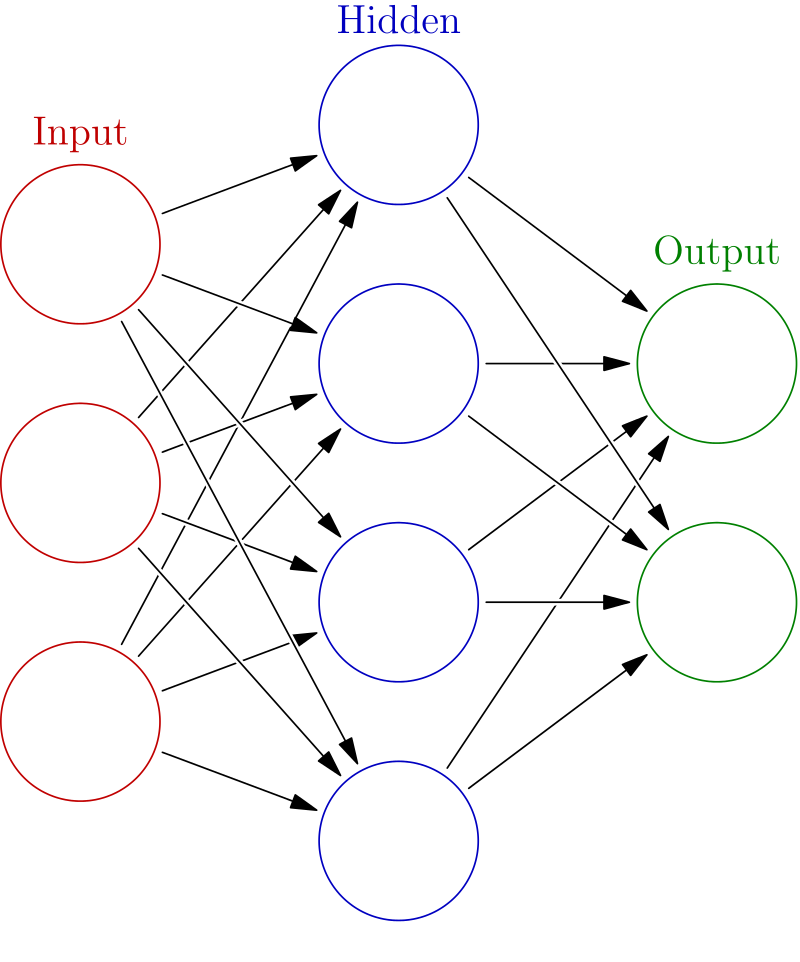

An artificial neural network is an interconnected group of nodes, inspired by a simplification of neurons in a brain. Here, each circular node represents an artificial neuron and an arrow represents a connection from the output of one artificial neuron to the input of another.

ANNs are composed of artificial neurons which are conceptually derived from biological neurons. Each artificial neuron has inputs and produce a single output which can be sent to multiple other neurons. The inputs can be the feature values of a sample of external data, such as images or documents, or they can be the outputs of other neurons. The outputs of the final output neurons of the neural net accomplish the task, such as recognizing an object in an image.

# Libraries and Data Importation

```python
# Import libraries
import pandas as pd
import numpy as np
import matplotlib.pyplot as plt
import seaborn as sns
```

```python
# Import data
df = pd.read_csv('lending_club_loan.csv')
```

# Data Exploration

```python
# Check dataframe
df.head()
```

|  | loan_amnt | term | int_rate | installment | grade | sub_grade | emp_title | emp_length | home_ownership | annual_inc | ... | open_acc | pub_rec | revol_bal | revol_util | total_acc | initial_list_status | application_type | mort_acc | pub_rec_bankruptcies | address |
| --- | --- | --- | --- | --- | --- | --- | --- | --- | --- | --- | --- | --- | --- | --- | --- | --- | --- | --- | --- | --- | --- |
| 0 | 10000.0 | 36 months | 11.44 | 329.48 | B | B4 | Marketing | 10+ years | RENT | 117000.0 | ... | 16.0 | 0.0 | 36369.0 | 41.8 | 25.0 | w | INDIVIDUAL | 0.0 | 0.0 | 0174 Michelle Gateway\r\nMendozaberg, OK 22690 |
| 1 | 8000.0 | 36 months | 11.99 | 265.68 | B | B5 | Credit analyst | 4 years | MORTGAGE | 65000.0 | ... | 17.0 | 0.0 | 20131.0 | 53.3 | 27.0 | f | INDIVIDUAL | 3.0 | 0.0 | 1076 Carney Fort Apt. 347\r\nLoganmouth, SD 05113 |
| 2 | 15600.0 | 36 months | 10.49 | 506.97 | B | B3 | Statistician | < 1 year | RENT | 43057.0 | ... | 13.0 | 0.0 | 11987.0 | 92.2 | 26.0 | f | INDIVIDUAL | 0.0 | 0.0 | 87025 Mark Dale Apt. 269\r\nNew Sabrina, WV 05113 |
| 3 | 7200.0 | 36 months | 6.49 | 220.65 | A | A2 | Client Advocate | 6 years | RENT | 54000.0 | ... | 6.0 | 0.0 | 5472.0 | 21.5 | 13.0 | f | INDIVIDUAL | 0.0 | 0.0 | 823 Reid Ford\r\nDelacruzside, MA 00813 |
| 4 | 24375.0 | 60 months | 17.27 | 609.33 | C | C5 | Destiny Management Inc. | 9 years | MORTGAGE | 55000.0 | ... | 13.0 | 0.0 | 24584.0 | 69.8 | 43.0 | f | INDIVIDUAL | 1.0 | 0.0 | 679 Luna Roads\r\nGreggshire, VA 11650 |

5 rows × 27 columns

```python
# Check data statistics
df.describe()
```

|  | loan_amnt | int_rate | installment | annual_inc | dti | open_acc | pub_rec | revol_bal | revol_util | total_acc | mort_acc | pub_rec_bankruptcies |
| --- | --- | --- | --- | --- | --- | --- | --- | --- | --- | --- | --- | --- |
| count | 396030.000000 | 396030.000000 | 396030.000000 | 3.960300e+05 | 396030.000000 | 396030.000000 | 396030.000000 | 3.960300e+05 | 395754.000000 | 396030.000000 | 358235.000000 | 395495.000000 |
| mean | 14113.888089 | 13.639400 | 431.849698 | 7.420318e+04 | 17.379514 | 11.311153 | 0.178191 | 1.584454e+04 | 53.791749 | 25.414744 | 1.813991 | 0.121648 |
| std | 8357.441341 | 4.472157 | 250.727790 | 6.163762e+04 | 18.019092 | 5.137649 | 0.530671 | 2.059184e+04 | 24.452193 | 11.886991 | 2.147930 | 0.356174 |
| min | 500.000000 | 5.320000 | 16.080000 | 0.000000e+00 | 0.000000 | 0.000000 | 0.000000 | 0.000000e+00 | 0.000000 | 2.000000 | 0.000000 | 0.000000 |
| 25% | 8000.000000 | 10.490000 | 250.330000 | 4.500000e+04 | 11.280000 | 8.000000 | 0.000000 | 6.025000e+03 | 35.800000 | 17.000000 | 0.000000 | 0.000000 |
| 50% | 12000.000000 | 13.330000 | 375.430000 | 6.400000e+04 | 16.910000 | 10.000000 | 0.000000 | 1.118100e+04 | 54.800000 | 24.000000 | 1.000000 | 0.000000 |
| 75% | 20000.000000 | 16.490000 | 567.300000 | 9.000000e+04 | 22.980000 | 14.000000 | 0.000000 | 1.962000e+04 | 72.900000 | 32.000000 | 3.000000 | 0.000000 |
| max | 40000.000000 | 30.990000 | 1533.810000 | 8.706582e+06 | 9999.000000 | 90.000000 | 86.000000 | 1.743266e+06 | 892.300000 | 151.000000 | 34.000000 | 8.000000 |

```python
# Check more info
df.info()
```

```
<class 'pandas.core.frame.DataFrame'>
RangeIndex: 396030 entries, 0 to 396029
Data columns (total 27 columns):
 #   Column                Non-Null Count   Dtype
---  ------                --------------   -----
 0   loan_amnt             396030 non-null  float64
 1   term                  396030 non-null  object
 2   int_rate              396030 non-null  float64
 3   installment           396030 non-null  float64
 4   grade                 396030 non-null  object
 5   sub_grade             396030 non-null  object
 6   emp_title             373103 non-null  object
 7   emp_length            377729 non-null  object
 8   home_ownership        396030 non-null  object
 9   annual_inc            396030 non-null  float64
```

[output cut: 19 more lines]

# Data Visualizaton

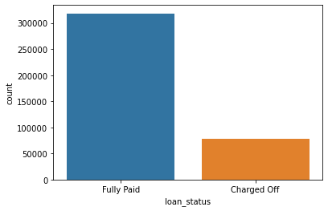

```python
# Visualize data
sns.countplot(x = 'loan_status' , data = df)
plt.show()
```

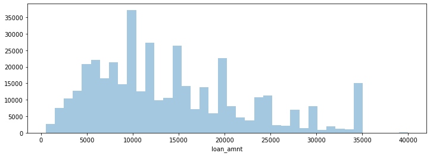

```python
# visualize data
plt.figure(figsize = (12,4))
sns.distplot(df['loan_amnt'], kde = False, bins = 40)
plt.show()
```

```python
# Check data correlation
df.corr()
```

|  | loan_amnt | int_rate | installment | annual_inc | dti | open_acc | pub_rec | revol_bal | revol_util | total_acc | mort_acc | pub_rec_bankruptcies |
| --- | --- | --- | --- | --- | --- | --- | --- | --- | --- | --- | --- | --- |
| loan_amnt | 1.000000 | 0.168921 | 0.953929 | 0.336887 | 0.016636 | 0.198556 | -0.077779 | 0.328320 | 0.099911 | 0.223886 | 0.222315 | -0.106539 |
| int_rate | 0.168921 | 1.000000 | 0.162758 | -0.056771 | 0.079038 | 0.011649 | 0.060986 | -0.011280 | 0.293659 | -0.036404 | -0.082583 | 0.057450 |
| installment | 0.953929 | 0.162758 | 1.000000 | 0.330381 | 0.015786 | 0.188973 | -0.067892 | 0.316455 | 0.123915 | 0.202430 | 0.193694 | -0.098628 |
| annual_inc | 0.336887 | -0.056771 | 0.330381 | 1.000000 | -0.081685 | 0.136150 | -0.013720 | 0.299773 | 0.027871 | 0.193023 | 0.236320 | -0.050162 |
| dti | 0.016636 | 0.079038 | 0.015786 | -0.081685 | 1.000000 | 0.136181 | -0.017639 | 0.063571 | 0.088375 | 0.102128 | -0.025439 | -0.014558 |
| open_acc | 0.198556 | 0.011649 | 0.188973 | 0.136150 | 0.136181 | 1.000000 | -0.018392 | 0.221192 | -0.131420 | 0.680728 | 0.109205 | -0.027732 |
| pub_rec | -0.077779 | 0.060986 | -0.067892 | -0.013720 | -0.017639 | -0.018392 | 1.000000 | -0.101664 | -0.075910 | 0.019723 | 0.011552 | 0.699408 |
| revol_bal | 0.328320 | -0.011280 | 0.316455 | 0.299773 | 0.063571 | 0.221192 | -0.101664 | 1.000000 | 0.226346 | 0.191616 | 0.194925 | -0.124532 |
| revol_util | 0.099911 | 0.293659 | 0.123915 | 0.027871 | 0.088375 | -0.131420 | -0.075910 | 0.226346 | 1.000000 | -0.104273 | 0.007514 | -0.086751 |
| total_acc | 0.223886 | -0.036404 | 0.202430 | 0.193023 | 0.102128 | 0.680728 | 0.019723 | 0.191616 | -0.104273 | 1.000000 | 0.381072 | 0.042035 |
| mort_acc | 0.222315 | -0.082583 | 0.193694 | 0.236320 | -0.025439 | 0.109205 | 0.011552 | 0.194925 | 0.007514 | 0.381072 | 1.000000 | 0.027239 |
| pub_rec_bankruptcies | -0.106539 | 0.057450 | -0.098628 | -0.050162 | -0.014558 | -0.027732 | 0.699408 | -0.124532 | -0.086751 | 0.042035 | 0.027239 | 1.000000 |

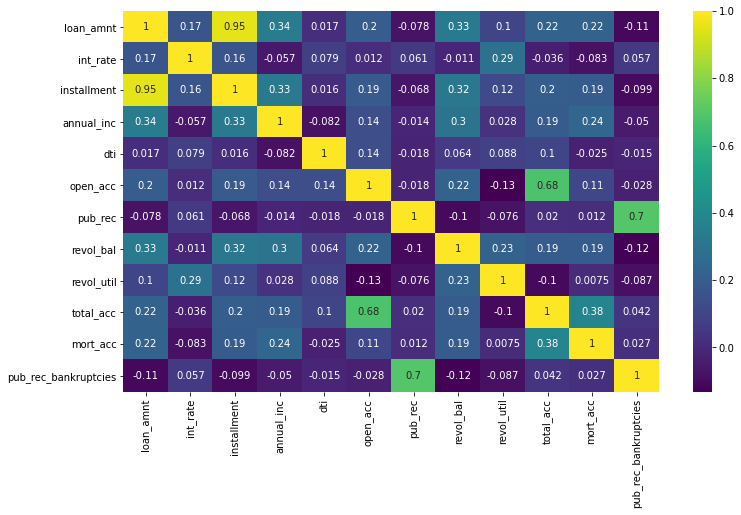

```python
# Visualize data correlation
plt.figure(figsize = (12, 7))
sns.heatmap(df.corr(), annot = True, cmap = 'viridis')
plt.show()
```

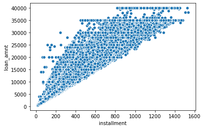

```python
# visualize data
sns.scatterplot(x = 'installment', y = 'loan_amnt', data = df)
plt.show()
```

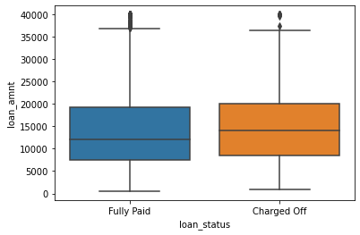

```python
# Visualize data
sns.boxplot(x = 'loan_status', y = 'loan_amnt', data = df)
plt.show()
```

```python
# Check summary statistics
df.groupby('loan_status')['loan_amnt'].describe()
```

| loan_status | count | mean | std | min | 25% | 50% | 75% | max |
| --- | --- | --- | --- | --- | --- | --- | --- | --- |
| Charged Off | 77673.0 | 15126.300967 | 8505.090557 | 1000.0 | 8525.0 | 14000.0 | 20000.0 | 40000.0 |
| Fully Paid | 318357.0 | 13866.878771 | 8302.319699 | 500.0 | 7500.0 | 12000.0 | 19225.0 | 40000.0 |

```python
# Check for unique values
df['grade'].unique()
```

```
array(['B', 'A', 'C', 'E', 'D', 'F', 'G'], dtype=object)
```

```python
# Check for unique values
df['sub_grade'].unique()
```

```
array(['B4', 'B5', 'B3', 'A2', 'C5', 'C3', 'A1', 'B2', 'C1', 'A5', 'E4',
       'A4', 'A3', 'D1', 'C2', 'B1', 'D3', 'D5', 'D2', 'E1', 'E2', 'E5',
       'F4', 'E3', 'D4', 'G1', 'F5', 'G2', 'C4', 'F1', 'F3', 'G5', 'G4',
       'F2', 'G3'], dtype=object)
```

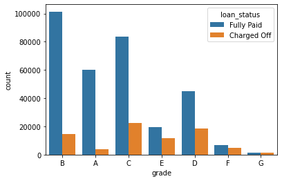

```python
# Visualize data
sns.countplot(x = 'grade', data = df, hue = 'loan_status')
plt.show()
```

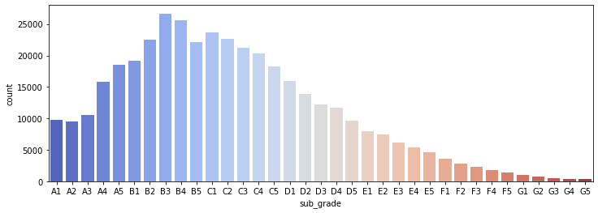

```python
# Visualize data
plt.figure(figsize = (12, 4))
subgrade_order = sorted(df['sub_grade'].unique())
sns.countplot(x = 'sub_grade', data = df, order = subgrade_order, palette = 'coolwarm')
plt.show()
```

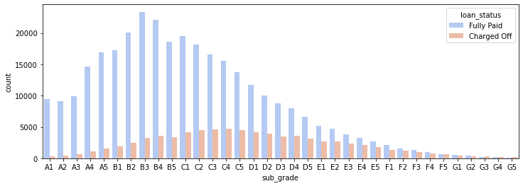

```python
# Visualize data
plt.figure(figsize = (12, 4))
subgrade_order = sorted(df['sub_grade'].unique())
sns.countplot(x = 'sub_grade', data = df, order = subgrade_order, palette = 'coolwarm', hue = 'loan_status')
plt.show()
```

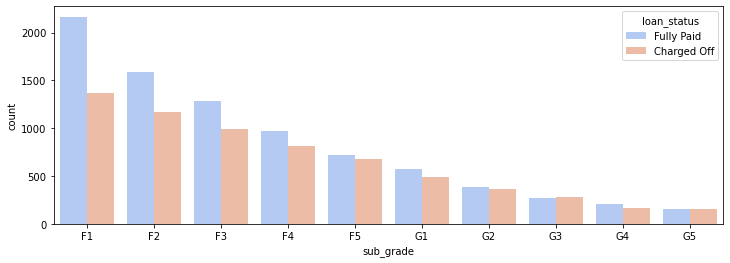

```python
# Visualize data
f_and_g = df[(df['grade'] == 'G') | (df['grade'] == 'F')]

plt.figure(figsize = (12, 4))
subgrade_order = sorted(f_and_g['sub_grade'].unique())
sns.countplot(x = 'sub_grade', data = f_and_g, order = subgrade_order, palette = 'coolwarm', hue = 'loan_status')
plt.show()
```

```python
# Create new column
df['loan_repaid'] = df['loan_status'].map({'Fully Paid': 1, 'Charged Off': 0})
```

```python
# Check dataframe
df[['loan_repaid', 'loan_status']]
```

|  | loan_repaid | loan_status |
| --- | --- | --- |
| 0 | 1 | Fully Paid |
| 1 | 1 | Fully Paid |
| 2 | 1 | Fully Paid |
| 3 | 1 | Fully Paid |
| 4 | 0 | Charged Off |
| ... | ... | ... |
| 396025 | 1 | Fully Paid |
| 396026 | 1 | Fully Paid |
| 396027 | 1 | Fully Paid |
| 396028 | 1 | Fully Paid |
| 396029 | 1 | Fully Paid |

396030 rows × 2 columns

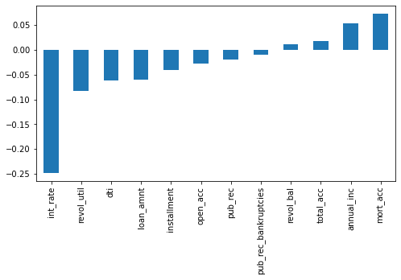

```python
# Visualize correlation impact
plt.figure(figsize = (8, 4))
df.corr()['loan_repaid'].sort_values().drop('loan_repaid').plot(kind = 'bar')
plt.show()
```

# Data Preprocessing

## Feature Engineering

```python
# Check dataframe length
len(df)
```

```
396030
```

```python
# Check for missing values
df.isnull().mean()
```

```
loan_amnt               0.000000
term                    0.000000
int_rate                0.000000
installment             0.000000
grade                   0.000000
sub_grade               0.000000
emp_title               0.057892
emp_length              0.046211
home_ownership          0.000000
annual_inc              0.000000
verification_status     0.000000
issue_d                 0.000000
loan_status             0.000000
purpose                 0.000000
title                   0.004431
dti                     0.000000
earliest_cr_line        0.000000
open_acc                0.000000
pub_rec                 0.000000
revol_bal               0.000000
revol_util              0.000697
total_acc               0.000000
initial_list_status     0.000000
application_type        0.000000
mort_acc                0.095435
pub_rec_bankruptcies    0.001351
address                 0.000000
loan_repaid             0.000000
dtype: float64
```

```python
# Check the percentage of missing data
(df.isnull().sum() / len(df)) * 100
```

```
loan_amnt               0.000000
term                    0.000000
int_rate                0.000000
installment             0.000000
grade                   0.000000
sub_grade               0.000000
emp_title               5.789208
emp_length              4.621115
home_ownership          0.000000
annual_inc              0.000000
verification_status     0.000000
issue_d                 0.000000
loan_status             0.000000
purpose                 0.000000
title                   0.443148
dti                     0.000000
earliest_cr_line        0.000000
open_acc                0.000000
pub_rec                 0.000000
revol_bal               0.000000
revol_util              0.069692
total_acc               0.000000
initial_list_status     0.000000
application_type        0.000000
mort_acc                9.543469
pub_rec_bankruptcies    0.135091
address                 0.000000
loan_repaid             0.000000
dtype: float64
```

```python
# Check data unique counts
df['emp_title'].nunique()
```

```
173105
```

```python
# check for value counts
df['emp_title'].value_counts()
```

```
Teacher                              4389
Manager                              4250
Registered Nurse                     1856
RN                                   1846
Supervisor                           1830
                                     ...
Kforce-Lockheed Martin                  1
Analytical technician                   1
Florida Department of Agriculture       1
Solid surfe fabricator                  1
Cheyenne Mountain Zoo                   1
Name: emp_title, Length: 173105, dtype: int64
```

```python
# Drop column
df = df.drop('emp_title', axis = 1)
```

```python
# check and dort data column
sorted(df['emp_length'].dropna().unique())
```

```
['1 year',
 '10+ years',
 '2 years',
 '3 years',
 '4 years',
 '5 years',
 '6 years',
 '7 years',
 '8 years',
 '9 years',
 '< 1 year']
```

```python
# Rearrange column data
emp_length_order  = [
 '< 1 year'
 '1 year',
 '2 years',
 '3 years',
 '4 years',
 '5 years',
 '6 years',
 '7 years',
 '8 years',
 '9 years',
 '10+ years']
```

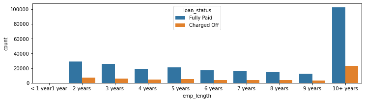

```python
# Visualize data
plt.figure(figsize = (12, 3))
sns.countplot(x = 'emp_length', data = df, order = emp_length_order, hue = 'loan_status')
plt.show()
```

```python
# Create filtered dataframe
emp_co = df[df['loan_status'] == 'Charged Off'].groupby('emp_length').count()['loan_status']

# Check dataframe
emp_co
```

```
emp_length
1 year        5154
10+ years    23215
2 years       6924
3 years       6182
4 years       4608
5 years       5092
6 years       3943
7 years       4055
8 years       3829
9 years       3070
< 1 year      6563
Name: loan_status, dtype: int64
```

```python
# Create filtered dataframe
emp_fp = df[df['loan_status'] == 'Fully Paid'].groupby('emp_length').count()['loan_status']

# Check dataframe
emp_fp
```

```
emp_length
1 year        20728
10+ years    102826
2 years       28903
3 years       25483
4 years       19344
5 years       21403
6 years       16898
7 years       16764
8 years       15339
9 years       12244
< 1 year      25162
Name: loan_status, dtype: int64
```

```python
# Check ratio
emp_co / emp_fp
```

```
emp_length
1 year       0.248649
10+ years    0.225770
2 years      0.239560
3 years      0.242593
4 years      0.238213
5 years      0.237911
6 years      0.233341
7 years      0.241887
8 years      0.249625
9 years      0.250735
< 1 year     0.260830
Name: loan_status, dtype: float64
```

```python
# Create label
emp_len = emp_co / (emp_co + emp_fp)
```

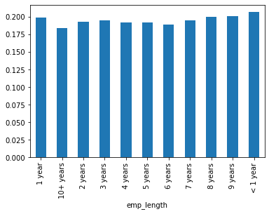

```python
# Visualize data
emp_len.plot(kind = 'bar')
plt.show()
```

```python
# Drop column
df = df.drop('emp_length', axis = 1)
```

```python
# Check data column
df['purpose'].head(10)
```

```
0              vacation
1    debt_consolidation
2           credit_card
3           credit_card
4           credit_card
5    debt_consolidation
6      home_improvement
7           credit_card
8    debt_consolidation
9    debt_consolidation
Name: purpose, dtype: object
```

```python
# Check data column
df['title'].head(10)
```

```
0                   Vacation
1         Debt consolidation
2    Credit card refinancing
3    Credit card refinancing
4      Credit Card Refinance
5         Debt consolidation
6           Home improvement
7       No More Credit Cards
8         Debt consolidation
9         Debt Consolidation
Name: title, dtype: object
```

```python
# Drop column
df = df.drop('title', axis = 1)
```

```python
# Check data column value counts
df['mort_acc'].value_counts()
```

```
0.0     139777
1.0      60416
2.0      49948
3.0      38049
4.0      27887
5.0      18194
6.0      11069
7.0       6052
8.0       3121
9.0       1656
10.0       865
11.0       479
12.0       264
13.0       146
14.0       107
15.0        61
16.0        37
17.0        22
18.0        18
19.0        15
20.0        13
24.0        10
22.0         7
21.0         4
25.0         4
27.0         3
23.0         2
32.0         2
26.0         2
31.0         2
30.0         1
28.0         1
34.0         1
Name: mort_acc, dtype: int64
```

```python
# Check specified correlation
df.corr()['mort_acc'].sort_values()
```

```
int_rate               -0.082583
dti                    -0.025439
revol_util              0.007514
pub_rec                 0.011552
pub_rec_bankruptcies    0.027239
loan_repaid             0.073111
open_acc                0.109205
installment             0.193694
revol_bal               0.194925
loan_amnt               0.222315
annual_inc              0.236320
total_acc               0.381072
mort_acc                1.000000
Name: mort_acc, dtype: float64
```

```python
# compare each column by mean according to a specific column
df.groupby('total_acc').mean()
```

| total_acc | loan_amnt | int_rate | installment | annual_inc | dti | open_acc | pub_rec | revol_bal | revol_util | mort_acc | pub_rec_bankruptcies | loan_repaid |
| --- | --- | --- | --- | --- | --- | --- | --- | --- | --- | --- | --- | --- |
| 2.0 | 6672.222222 | 15.801111 | 210.881667 | 64277.777778 | 2.279444 | 1.611111 | 0.000000 | 2860.166667 | 53.527778 | 0.000000 | 0.000000 | 0.777778 |
| 3.0 | 6042.966361 | 15.615566 | 198.728318 | 41270.753884 | 6.502813 | 2.611621 | 0.045872 | 3382.807339 | 49.991022 | 0.052023 | 0.015480 | 0.779817 |
| 4.0 | 7587.399031 | 15.069491 | 250.050194 | 42426.565969 | 8.411963 | 3.324717 | 0.041195 | 4874.231826 | 58.477400 | 0.066743 | 0.022951 | 0.785945 |
| 5.0 | 7845.734714 | 14.917564 | 256.190325 | 44394.098003 | 10.118328 | 3.921598 | 0.071499 | 5475.253452 | 56.890311 | 0.103289 | 0.041171 | 0.796844 |
| 6.0 | 8529.019843 | 14.651752 | 278.518228 | 48470.001156 | 11.222542 | 4.511119 | 0.104003 | 6546.374957 | 57.812483 | 0.151293 | 0.055077 | 0.784126 |
| ... | ... | ... | ... | ... | ... | ... | ... | ... | ... | ... | ... | ... |
| 124.0 | 23200.000000 | 17.860000 | 587.370000 | 66000.000000 | 14.040000 | 43.000000 | 0.000000 | 25497.000000 | 75.400000 | 1.000000 | 0.000000 | 0.000000 |
| 129.0 | 25000.000000 | 7.890000 | 505.600000 | 200000.000000 | 8.900000 | 48.000000 | 0.000000 | 27659.000000 | 8.300000 | 1.000000 | 0.000000 | 1.000000 |
| 135.0 | 24000.000000 | 15.410000 | 576.140000 | 82000.000000 | 33.850000 | 57.000000 | 0.000000 | 35715.000000 | 50.800000 | 3.000000 | 0.000000 | 1.000000 |
| 150.0 | 35000.000000 | 8.670000 | 1107.630000 | 189000.000000 | 6.630000 | 40.000000 | 0.000000 | 39065.000000 | 44.400000 | 2.000000 | 0.000000 | 1.000000 |
| 151.0 | 35000.000000 | 13.990000 | 1196.050000 | 160000.000000 | 12.650000 | 26.000000 | 0.000000 | 46643.000000 | 71.500000 | 0.000000 | 0.000000 | 0.000000 |

118 rows × 12 columns

```python
# create new data frame
total_acc_avg = df.groupby('total_acc').mean()['mort_acc']

# Check dataframe
total_acc_avg
```

```
total_acc
2.0      0.000000
3.0      0.052023
4.0      0.066743
5.0      0.103289
6.0      0.151293
           ...
124.0    1.000000
129.0    1.000000
135.0    3.000000
150.0    2.000000
151.0    0.000000
Name: mort_acc, Length: 118, dtype: float64
```

```python
# Create function
def fill_mort_acc(total_acc, mort_acc):
    if np.isnan(mort_acc):
        return total_acc_avg[total_acc]
    else:
        return mort_acc
```

```python
df['mort_acc'] = df.apply(lambda x: fill_mort_acc(x['total_acc'], x['mort_acc']), axis = 1) # Lambda = apply function to two pandas dataframe
```

```python
# Check for missing values
df.isnull().mean()
```

```
loan_amnt               0.000000
term                    0.000000
int_rate                0.000000
installment             0.000000
grade                   0.000000
sub_grade               0.000000
home_ownership          0.000000
annual_inc              0.000000
verification_status     0.000000
issue_d                 0.000000
loan_status             0.000000
purpose                 0.000000
dti                     0.000000
earliest_cr_line        0.000000
open_acc                0.000000
pub_rec                 0.000000
revol_bal               0.000000
revol_util              0.000697
total_acc               0.000000
initial_list_status     0.000000
application_type        0.000000
mort_acc                0.000000
pub_rec_bankruptcies    0.001351
address                 0.000000
loan_repaid             0.000000
dtype: float64
```

```python
# Drop columns
df = df.dropna()
```

```python
# Check for missing values
df.isnull().mean()
```

```
loan_amnt               0.0
term                    0.0
int_rate                0.0
installment             0.0
grade                   0.0
sub_grade               0.0
home_ownership          0.0
annual_inc              0.0
verification_status     0.0
issue_d                 0.0
loan_status             0.0
purpose                 0.0
dti                     0.0
earliest_cr_line        0.0
open_acc                0.0
pub_rec                 0.0
revol_bal               0.0
revol_util              0.0
total_acc               0.0
initial_list_status     0.0
application_type        0.0
mort_acc                0.0
pub_rec_bankruptcies    0.0
address                 0.0
loan_repaid             0.0
dtype: float64
```

## Categorical Encoding

```python
# Check string columns
df.select_dtypes(['object']).columns
```

```
Index(['term', 'grade', 'sub_grade', 'home_ownership', 'verification_status',
       'issue_d', 'loan_status', 'purpose', 'earliest_cr_line',
       'initial_list_status', 'application_type', 'address'],
      dtype='object')
```

```python
# Check value counts
df['term'].value_counts()
```

```
 36 months    301247
 60 months     93972
Name: term, dtype: int64
```

```python
# Take only the first two characters
df['term'] = df['term'].apply(lambda term: int(term[:3]))
```

```python
# Check data column
df['term'].value_counts()
```

```
36    301247
60     93972
Name: term, dtype: int64
```

```python
# Drop column
df = df.drop('grade', axis = 1)
```

```python
# Get dummies
dummies = pd.get_dummies(df['sub_grade'], drop_first = True)

# Removie the original column and concat the dummies
df = pd.concat([df.drop('sub_grade', axis = 1), dummies], axis = 1)
```

```python
# check data column
df.columns
```

```
Index(['loan_amnt', 'term', 'int_rate', 'installment', 'home_ownership',
       'annual_inc', 'verification_status', 'issue_d', 'loan_status',
       'purpose', 'dti', 'earliest_cr_line', 'open_acc', 'pub_rec',
       'revol_bal', 'revol_util', 'total_acc', 'initial_list_status',
       'application_type', 'mort_acc', 'pub_rec_bankruptcies', 'address',
       'loan_repaid', 'A2', 'A3', 'A4', 'A5', 'B1', 'B2', 'B3', 'B4', 'B5',
       'C1', 'C2', 'C3', 'C4', 'C5', 'D1', 'D2', 'D3', 'D4', 'D5', 'E1', 'E2',
       'E3', 'E4', 'E5', 'F1', 'F2', 'F3', 'F4', 'F5', 'G1', 'G2', 'G3', 'G4',
       'G5'],
      dtype='object')
```

```python
# Get dummies
dummies = pd.get_dummies(df[['verification_status', 'application_type', 'initial_list_status','purpose']], drop_first = True)

# Removie the original column and concat the dummies
df = pd.concat([df.drop(['verification_status', 'application_type','initial_list_status','purpose'], axis = 1), dummies], axis = 1)
```

```python
# Check value counts
df['home_ownership'].value_counts()
```

```
MORTGAGE    198022
RENT        159395
OWN          37660
OTHER          110
NONE            29
ANY              3
Name: home_ownership, dtype: int64
```

```python
# Replace values
df['home_ownership'] = df['home_ownership'].replace(['NONE', 'ANY'], 'OTHER')
```

```python
# Check value counts
df['home_ownership'].value_counts()
```

```
MORTGAGE    198022
RENT        159395
OWN          37660
OTHER          142
Name: home_ownership, dtype: int64
```

```python
# Get dummies
dummies = pd.get_dummies(df['home_ownership'], drop_first = True)

# Removie the original column and concat the dummies
df = pd.concat([df.drop('home_ownership', axis = 1), dummies], axis = 1)
```

```python
# Check dataframe
df.head()
```

|  | loan_amnt | term | int_rate | installment | annual_inc | issue_d | loan_status | dti | earliest_cr_line | open_acc | ... | purpose_medical | purpose_moving | purpose_other | purpose_renewable_energy | purpose_small_business | purpose_vacation | purpose_wedding | OTHER | OWN | RENT |
| --- | --- | --- | --- | --- | --- | --- | --- | --- | --- | --- | --- | --- | --- | --- | --- | --- | --- | --- | --- | --- | --- |
| 0 | 10000.0 | 36 | 11.44 | 329.48 | 117000.0 | Jan-2015 | Fully Paid | 26.24 | Jun-1990 | 16.0 | ... | 0 | 0 | 0 | 0 | 0 | 1 | 0 | 0 | 0 | 1 |
| 1 | 8000.0 | 36 | 11.99 | 265.68 | 65000.0 | Jan-2015 | Fully Paid | 22.05 | Jul-2004 | 17.0 | ... | 0 | 0 | 0 | 0 | 0 | 0 | 0 | 0 | 0 | 0 |
| 2 | 15600.0 | 36 | 10.49 | 506.97 | 43057.0 | Jan-2015 | Fully Paid | 12.79 | Aug-2007 | 13.0 | ... | 0 | 0 | 0 | 0 | 0 | 0 | 0 | 0 | 0 | 1 |
| 3 | 7200.0 | 36 | 6.49 | 220.65 | 54000.0 | Nov-2014 | Fully Paid | 2.60 | Sep-2006 | 6.0 | ... | 0 | 0 | 0 | 0 | 0 | 0 | 0 | 0 | 0 | 1 |
| 4 | 24375.0 | 60 | 17.27 | 609.33 | 55000.0 | Apr-2013 | Charged Off | 33.95 | Mar-1999 | 13.0 | ... | 0 | 0 | 0 | 0 | 0 | 0 | 0 | 0 | 0 | 0 |

5 rows × 73 columns

```python
# Check column
df['address']
```

```
0            0174 Michelle Gateway\r\nMendozaberg, OK 22690
1         1076 Carney Fort Apt. 347\r\nLoganmouth, SD 05113
2         87025 Mark Dale Apt. 269\r\nNew Sabrina, WV 05113
3                   823 Reid Ford\r\nDelacruzside, MA 00813
4                    679 Luna Roads\r\nGreggshire, VA 11650
                                ...
396025     12951 Williams Crossing\r\nJohnnyville, DC 30723
396026    0114 Fowler Field Suite 028\r\nRachelborough, ...
396027    953 Matthew Points Suite 414\r\nReedfort, NY 7...
396028    7843 Blake Freeway Apt. 229\r\nNew Michael, FL...
396029        787 Michelle Causeway\r\nBriannaton, AR 48052
Name: address, Length: 395219, dtype: object
```

```python
# Take last five characters
df['zip_code'] = df['address'].apply(lambda address:address[-5:])

# Check data column
df['zip_code']
```

```
0         22690
1         05113
2         05113
3         00813
4         11650
          ...
396025    30723
396026    05113
396027    70466
396028    29597
396029    48052
Name: zip_code, Length: 395219, dtype: object
```

```python
# Check value counts
df['zip_code'].value_counts()
```

```
70466    56880
22690    56413
30723    56402
48052    55811
00813    45725
29597    45393
05113    45300
11650    11210
93700    11126
86630    10959
Name: zip_code, dtype: int64
```

```python
# Get dummies
dummies = pd.get_dummies(df['zip_code'], drop_first = True)

# Removie the original column and concat the dummies
df = pd.concat([df.drop('zip_code', axis = 1), dummies], axis = 1)

# Drop the original column
df = df.drop('address', axis = 1)
```

```python
# Drop column
df = df.drop('issue_d', axis = 1)
```

```python
# Check data column
df['earliest_cr_line']
```

```
0         Jun-1990
1         Jul-2004
2         Aug-2007
3         Sep-2006
4         Mar-1999
            ...
396025    Nov-2004
396026    Feb-2006
396027    Mar-1997
396028    Nov-1990
396029    Sep-1998
Name: earliest_cr_line, Length: 395219, dtype: object
```

```python
# Get the last 4 characters
df['earliest_cr_line'] = df['earliest_cr_line'].apply(lambda date: int(date[-4:]))
```

```python
# Check data column
df['earliest_cr_line']
```

```
0         1990
1         2004
2         2007
3         2006
4         1999
          ...
396025    2004
396026    2006
396027    1997
396028    1990
396029    1998
Name: earliest_cr_line, Length: 395219, dtype: int64
```

## Data Splitting and Scaling

```python
# Drop data column
df = df.drop('loan_status', axis = 1)
```

```python
# Set the x and y variables
X = df.drop('loan_repaid', axis = 1).values
y = df['loan_repaid'].values
```

```python
# Import library
from sklearn.model_selection import train_test_split

# Split the data
X_train, X_test, y_train, y_test = train_test_split(X, y, test_size=0.20, random_state=42)
```

```python
# Import library
from sklearn.preprocessing import MinMaxScaler
scaler = MinMaxScaler()

# Normalize the data
X_train = scaler.fit_transform(X_train)
X_test = scaler.transform(X_test)
```

# Model Creation

```python
# Import libraries
import tensorflow as tf
from tensorflow.keras.models import Sequential
from tensorflow.keras.layers import Dense, Activation,Dropout
from tensorflow.keras.constraints import max_norm
```

```python
# Create model architecture
model = Sequential()

# Input layer
model.add(Dense(78,  activation='relu'))
model.add(Dropout(0.2))

# Hidden layer
model.add(Dense(39, activation='relu'))
model.add(Dropout(0.2))

# Hidden layer
model.add(Dense(19, activation='relu'))
model.add(Dropout(0.2))

# Output layer
model.add(Dense(units=1,activation='sigmoid'))

# Compile model
model.compile(loss='binary_crossentropy', optimizer='adam')
```

```python
# Train the model
model.fit(x=X_train,
          y=y_train,
          epochs=25,
          batch_size=256,
          validation_data=(X_test, y_test),
          )
```

```
<tensorflow.python.keras.callbacks.History at 0x1d612046d00>
```

# Model Evaluation

```python
# Check dataframe
pd.DataFrame(model.history.history)
```

|  | loss | val_loss |
| --- | --- | --- |
| 0 | 0.300101 | 0.262768 |
| 1 | 0.265768 | 0.261880 |
| 2 | 0.263329 | 0.260314 |
| 3 | 0.262459 | 0.259649 |
| 4 | 0.261652 | 0.259654 |
| 5 | 0.260856 | 0.259863 |
| 6 | 0.260470 | 0.259188 |
| 7 | 0.259991 | 0.259018 |
| 8 | 0.259822 | 0.259445 |
| 9 | 0.259569 | 0.258644 |
| 10 | 0.259577 | 0.258945 |
| 11 | 0.258858 | 0.258921 |
| 12 | 0.258878 | 0.258647 |
| 13 | 0.258598 | 0.258740 |
| 14 | 0.258404 | 0.258425 |
| 15 | 0.258042 | 0.258552 |
| 16 | 0.257948 | 0.259319 |
| 17 | 0.257684 | 0.258779 |
| 18 | 0.257482 | 0.258589 |
| 19 | 0.257214 | 0.258653 |
| 20 | 0.257455 | 0.258279 |
| 21 | 0.256869 | 0.258192 |
| 22 | 0.256862 | 0.258293 |
| 23 | 0.256762 | 0.258402 |
| 24 | 0.256617 | 0.258631 |

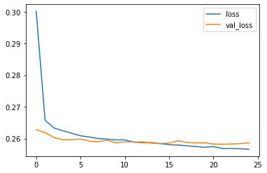

```python
# label the dataframe
losses = pd.DataFrame(model.history.history)

# Plot the evaluation metrics
losses[['loss','val_loss']].plot()
plt.show()
```

```python
# Import library
from sklearn.metrics import classification_report,confusion_matrix

# Set prediction
predictions = model.predict_classes(X_test)
print(classification_report(y_test,predictions))
```

```
              precision    recall  f1-score   support

           0       0.95      0.45      0.61     15421
           1       0.88      0.99      0.94     63623

    accuracy                           0.89     79044
   macro avg       0.92      0.72      0.77     79044
weighted avg       0.90      0.89      0.87     79044
```

```python
# Check confusion matrix
confusion_matrix(y_test,predictions)
```

```
array([[ 6991,  8430],
       [  355, 63268]], dtype=int64)
```

# Sample Prediction

```python
# Create sample
import random
random.seed(101)
random_ind = random.randint(0,len(df))

new_customer = df.drop('loan_repaid', axis=1).iloc[random_ind]
new_customer
```

```
loan_amnt      25000.00
term              60.00
int_rate          18.24
installment      638.11
annual_inc     61665.00
                 ...
30723              1.00
48052              0.00
70466              0.00
86630              0.00
93700              0.00
Name: 305323, Length: 78, dtype: float64
```

```python
# Predict Sample
model.predict_classes(new_customer.values.reshape(1,78))
```

```
array([[1]])
```

```python
# True value
df.iloc[random_ind]['loan_repaid']
```

```
1.0
```

# Save Model

```python
# Import library
from tensorflow.keras.models import load_model

# Save the model
model.save('full_data_project_model.h5')
```

# Conclusion

The model was able to obtained 89% accuracy but there was an issue, the dataset was imbalance. There were more 'Fully paid' than 'Charged off' which has a probability of 80% by just guessing Fully Paid. Possible solution for that is Re-sampling the training dataset (Under-sampling or over-sampling and then apply k-fold cross validation.